# Clustering method

Now, performing the k-means clustering:

```r
k=kmeans(pharma.norm.df,centers=5,nstart = 10)
```

Following are the centers:

```r
k$centers
```

```
   Market_Cap       Beta    PE_Ratio        ROE        ROA Asset_Turnover
1 -0.87051511  1.3409869 -0.05284434 -0.6184015 -1.1928478     -0.4612656
2 -0.43925134 -0.4701800  2.70002464 -0.8349525 -0.9234951      0.2306328
3 -0.03142211 -0.4360989 -0.31724852  0.1950459  0.4083915      0.1729746
4  1.69558112 -0.1780563 -0.19845823  1.2349879  1.3503431      1.1531640
5 -0.76022489  0.2796041 -0.47742380 -0.7438022 -0.8107428     -1.2684804
     Leverage Rev_Growth Net_Profit_Margin
1  1.36644699 -0.6912914      -1.320000179
2 -0.14170336 -0.1168459      -1.416514761
3 -0.27449312 -0.7041516       0.556954446
4 -0.46807818  0.4671788       0.591242521
5  0.06308085  1.5180158      -0.006893899
```

Following are sizes the clusters:

```r
k$size
```

```
[1] 3 2 8 4 4
```

Clustering can be visualized as:

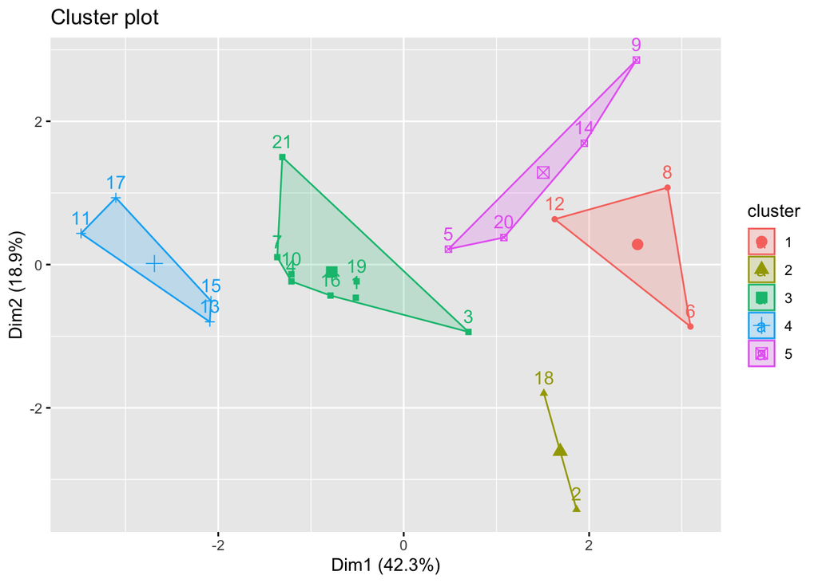

```r
fviz_cluster(k,data = pharma.norm.df)
```

**Interpretation:**

K-means plot shows us an optimum picture of clusters. All points which are close to each other are in one cluster. Also, it’s easy to study the structure of given using this kind of uniform cluster plot.

- **DBSCAN:**

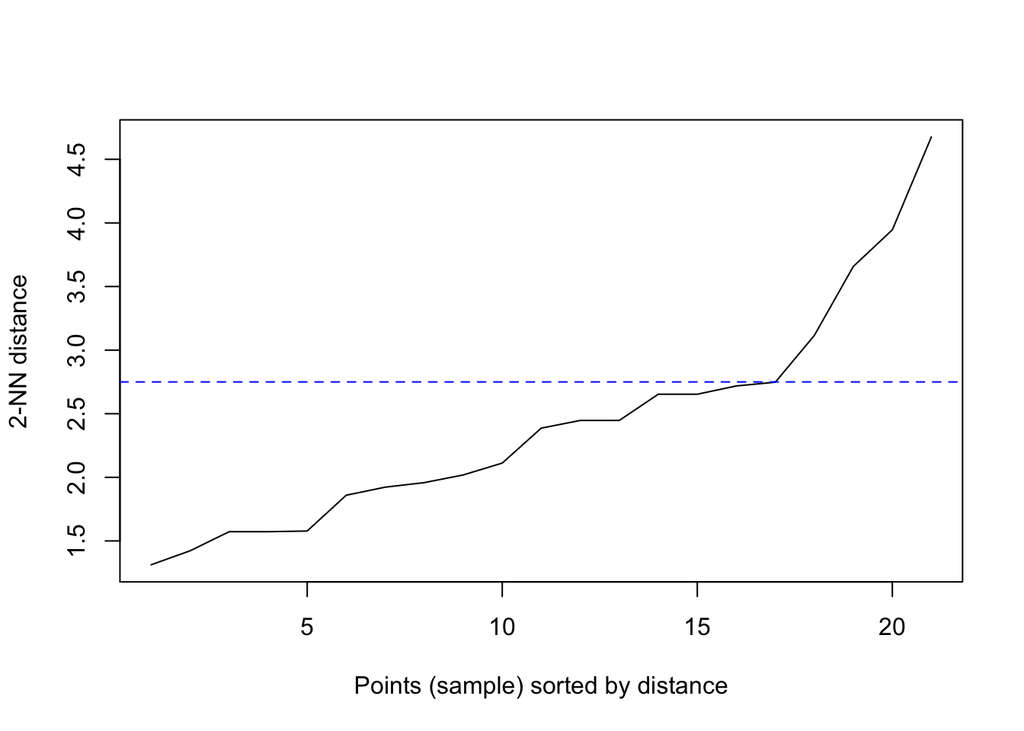

```r
dbscan::kNNdistplot(pharma.norm.df,k=2)
abline(h=2.75,lty="dashed",col="blue")
```

Hence, value of eps=2.75 (knee-point) is optimum and we can construct a dbscan model on this.

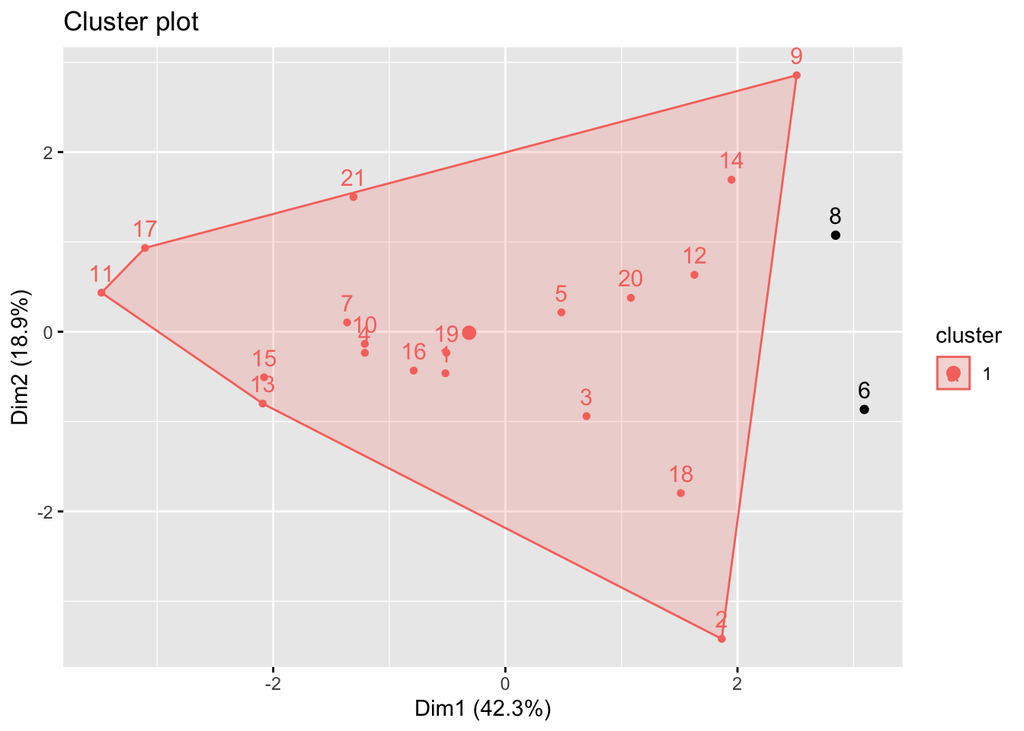

```r
db= dbscan::dbscan(pharma.norm.df,eps=2.75,minPts = 2)
fviz_cluster(db,pharma.norm.df)
```

**Interpretation:**

DBSCAN method seems to be a wrong method for clustering the given data because it keeps almost all of the data points in a single cluster. Also, if a smaller value of eps is chosen then it keeps most of the points as outliers. Hence, DBSCAN is not an optimum method for given data.

- **Hierarchical Method:**

Applying hclust directly

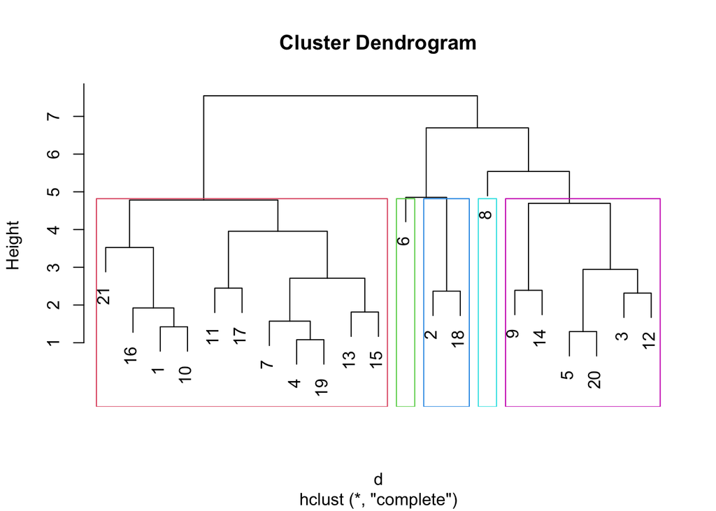

```r
d=dist(pharma.norm.df,method = "euclidean")
hc=hclust(d,method = "complete")
plot(hc)
rect.hclust(hc,k=5,border = 2:7)
```

**Interpretations:**

Hierarchical though gives us a seemingly nice picture of clusters, when we try to make 5 clusters like k-means with it, it presents some outliers which are indeed close to some other points when compared to k-means plot and instead should be considered in a cluster with other points. Also, there is no hierarchy in financial data and hence doing a hierarchical clustering doesn’t make any sense .This method too seems to be lacking behind of k-means method in organizing the data into clusters.

**Justification of choices made:**

1. Since there is no indication in question regarding weightage of variables, we have normalized data and hence given equal weightage to all variables.
2. After trying out different clustering methods, I figured out that k-means method is the best method for given data because it gives us a better clustered picture of data with all points which are closer to each other are in same cluster.
3. We have used methods like elbow-method and distplot to find the values of k and eps in order to determine the number of clusters we need. Also, in hierarchical plot we kept number of clusters as 5 just so that we can compare it with K-means clustering.

**Q:Interpret the clusters with respect to the numerical variables used in forming the clusters. Is there a pattern in the clusters with respect to the numerical variables (10 to 12)? (those not used in forming the clusters)**

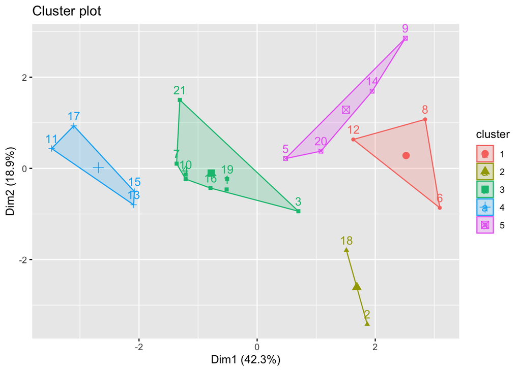

```r
fviz_cluster(k,data = pharma.norm.df)
```

- With respect to numerical values used in the clustering, the numerical values of points in same k-means clusters are close to each other as compared points in different groups. We can view these clusters to interpret better.

Cluster-1:

```r
kable(pharma.norm.df[c(6,8,12),],align = "c")
```

|  | Market_Cap | Beta | PE_Ratio | ROE | ROA | Asset_Turnover | Leverage | Rev_Growth | Net_Profit_Margin |
| --- | --- | --- | --- | --- | --- | --- | --- | --- | --- |
| 6 | -0.6953818 | 2.2757827 | 0.1494823 | -1.4514600 | -1.7127612 | -0.4612656 | -0.7496565 | -1.4971443 | -1.9956023 |
| 8 | -0.9767669 | 1.2630872 | 0.0329912 | -0.1123792 | -1.1677918 | -0.4612656 | 3.7427970 | -0.6327607 | -1.2488842 |
| 12 | -0.9393967 | 0.4840907 | -0.3410066 | -0.2913653 | -0.6979905 | -0.4612656 | 1.1062004 | 0.0560309 | -0.7155141 |

This cluster has high Beta values, average PE-ratio and all other variables are below average values.However, leverage and Rev_growth have mixed values.

Cluster-2:

```r
kable(pharma.norm.df[c(2,18),],align = "c")
```

|  | Market_Cap | Beta | PE_Ratio | ROE | ROA | Asset_Turnover | Leverage | Rev_Growth | Net_Profit_Margin |
| --- | --- | --- | --- | --- | --- | --- | --- | --- | --- |
| 2 | -0.8544181 | -0.4507051 | 3.497069 | -0.8548399 | -0.9422871 | 0.9225312 | 0.0182843 | -0.3811391 | -1.553667 |
| 18 | -0.0240846 | -0.4896550 | 1.902980 | -0.8150652 | -0.9047030 | -0.4612656 | -0.3016910 | 0.1474473 | -1.279362 |

This cluster has a high PE ratio but all other variables are lower than average. However, this cluster also has mixed values for leverage and rev_growth.

Cluster-3:

```r
kable(pharma.norm.df[c(1,3,4,7,10,16,19,21),],align = "c")
```

|  | Market_Cap | Beta | PE_Ratio | ROE | ROA | Asset_Turnover | Leverage | Rev_Growth | Net_Profit_Margin |
| --- | --- | --- | --- | --- | --- | --- | --- | --- | --- |
| 1 | 0.1840960 | -0.8012536 | -0.0467132 | 0.0400903 | 0.2416121 | 0.0000000 | -0.2120979 | -0.5277675 | 0.0616823 |
| 3 | -0.8762600 | -0.2559560 | -0.2919577 | -0.7222576 | -0.5100700 | 0.9225312 | -0.4040831 | -0.5721181 | -0.6850358 |
| 4 | 0.1702742 | -0.0222570 | -0.2429088 | 0.1063815 | 0.9181259 | 0.9225312 | -0.7496565 | 0.1474473 | 0.3512260 |
| 7 | -0.1078688 | -0.1001567 | -0.7088733 | 0.5969358 | 0.8617498 | 0.9225312 | -0.0201127 | -0.9658426 | 0.7474438 |
| 10 | 0.2762415 | -1.3465511 | 0.1494823 | 0.3450295 | 0.5610770 | -0.4612656 | -0.0713088 | -0.6481476 | 1.1741398 |
| 16 | 0.6654710 | -1.3076013 | -0.2367777 | -0.5233842 | 0.1288598 | -0.9225312 | -0.6728624 | -1.4536989 | 1.0217484 |
| 19 | -0.4018812 | -0.0612069 | -0.4023177 | -0.2118159 | 0.5234929 | 0.4612656 | -0.7496565 | -0.4354459 | 0.2902694 |
| 21 | -0.1614497 | 0.4061910 | -0.7579221 | 1.9293875 | 0.5422849 | -0.4612656 | 0.6838330 | -1.1776392 | 1.4941618 |

This cluster has very high Net_profit values. However, other variables have mixed values.

Cluster-4:

```r
kable(pharma.norm.df[c(11,17,15,13),],align = "c")
```

|  | Market_Cap | Beta | PE_Ratio | ROE | ROA | Asset_Turnover | Leverage | Rev_Growth | Net_Profit_Margin |
| --- | --- | --- | --- | --- | --- | --- | --- | --- | --- |
| 11 | 1.099920 | -0.6844041 | -0.4574977 | 2.4597165 | 1.8389364 | 1.3837968 | -0.3144900 | 0.7692605 | 0.8236395 |
| 17 | 2.419990 | 0.4840907 | -0.1141555 | 1.3128800 | 1.6322239 | 0.4612656 | -0.5448723 | 1.1014372 | 1.4484444 |
| 15 | 1.278239 | -0.2559560 | -0.4023177 | 0.9814243 | 0.8429577 | 1.8450624 | -0.3912841 | 0.3601491 | -0.2431006 |
| 13 | 1.984176 | -0.2559560 | 0.1801379 | 0.1859308 | 1.0872544 | 0.9225312 | -0.6216663 | -0.3621317 | 0.3359869 |

All companies in this cluster have high values. Besides, Beta, PE ratio and Leverage.

Cluster-5:

```r
kable(pharma.norm.df[c(5,9,14,20),],align = "c")
```

|  | Market_Cap | Beta | PE_Ratio | ROE | ROA | Asset_Turnover | Leverage | Rev_Growth | Net_Profit_Margin |
| --- | --- | --- | --- | --- | --- | --- | --- | --- | --- |
| 5 | -0.1790256 | -0.8012536 | -0.3287443 | -0.2648488 | -0.5664461 | -0.4612656 | -0.3144900 | 1.216387 | -0.4259704 |
| 9 | -0.9704532 | 2.1589332 | -1.3403777 | -0.7089994 | -1.0174553 | -1.8450624 | 0.6198379 | 1.886171 | -0.3650138 |
| 14 | -0.9632863 | 0.8735889 | 0.1924001 | -0.9675348 | -0.9610792 | -1.8450624 | 0.4406517 | 1.538607 | 0.8541178 |
| 20 | -0.9281345 | -1.1128522 | -0.4329732 | -1.0338259 | -0.6979905 | -0.9225312 | -0.4936762 | 1.430899 | -0.0907092 |

- Making barplots to check patters in variables we did not use in clustering.

Comparing recommendation of clusters-

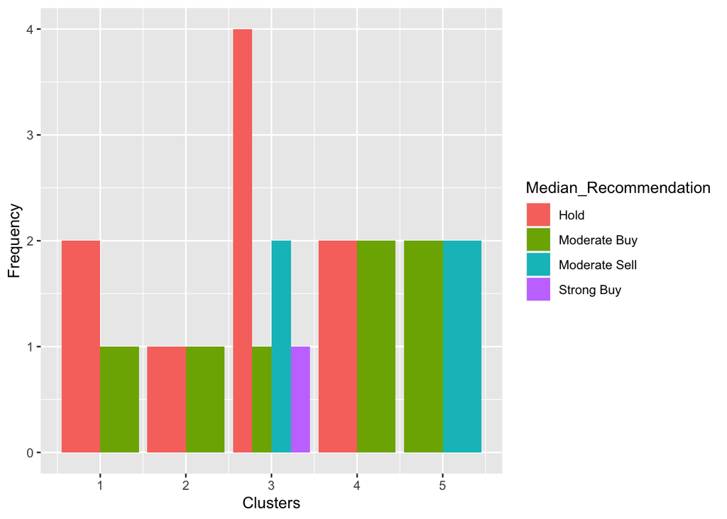

```r
df.2=df %>%
  select(c(1,12,13,14)) %>%
  mutate(cluster=k$cluster)
ggplot(df.2,mapping = aes(cluster,fill=Median_Recommendation))+
  geom_bar(position = 'dodge') +
  labs(x='Clusters',y='Frequency')
```

Comparing countries of clusters-

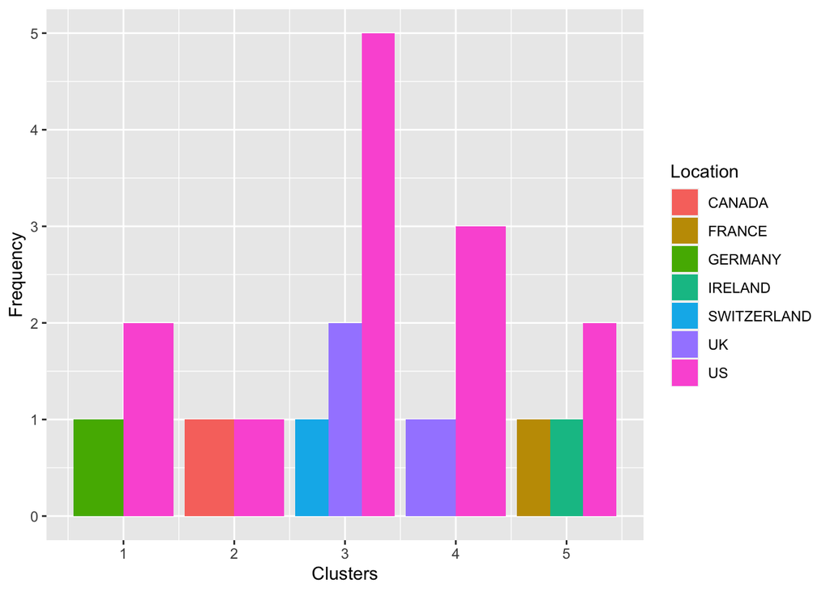

```r
ggplot(df.2,mapping = aes(cluster,fill=Location))+
  geom_bar(position = 'dodge') +
  labs(x='Clusters',y='Frequency')
```

Comparing stock-exchanges of clusters-

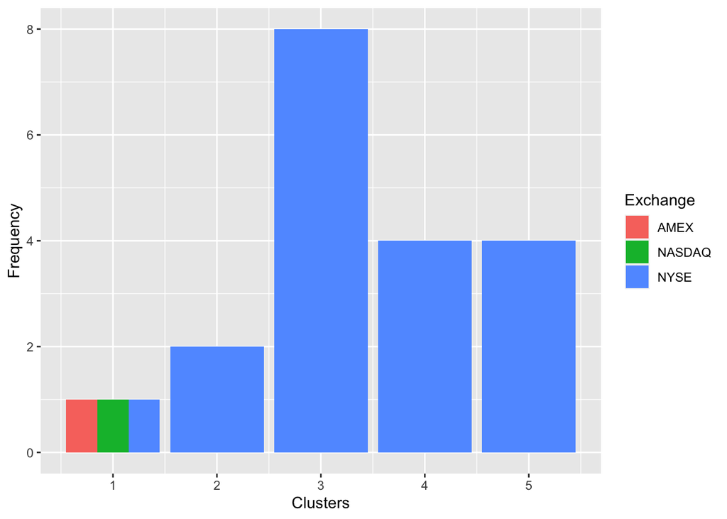

```r
ggplot(df.2,mapping = aes(cluster,fill=Exchange))+
  geom_bar(position = 'dodge') +
  labs(x='Clusters',y='Frequency')
```

**Interpretation:**

- Cluster-1: Companies are listed in all three exchanges and do business in USA and Germany. Recommendation is to Hold more companies and Moderate buy on some.
- Cluster-2: All companies are listed in NYSE and do business in Canada and USA. Recommendation is to hold half and moderate buy half companies.
- Cluster-3: All companies are listed in NYSE and do business in Switzerland, UK and US. Recommendation is mixed but most are recommended to be hold.
- Cluster- 4: All companies are listed in NYSE and do business in UK and US. Recommendation is to Moderate buy half and hold half.
- Cluster-5: All companies are listed in NYSE and do business in France, Ireland and US. Recommendation is to Moderate buy half and Moderate sell half.

**Q:Provide an appropriate name for each cluster using any or all of the variables in the dataset.**

- Cluster-1: Low cap Highly-Volatile companies.(Because of high Beta value and low profits and small market cap)
- Cluster-2: Small cap overpriced companies.(Because of higher PE ratio and smaller market cap)
- Cluster-3: Mid cap Profitable companies. (Most companies has above than average profits and have average market cap)
- Cluster-4: Large-cap Under-priced companies. (High Market cap and Lower than average PE ratio but all financials seem good)
- Cluster-5: Small cap Less-Profitable companies ( Smaller market cap and Profits are lower than average)